# Bayesian Geostatistics Using Predictive Stacking example code

Lu Zhang

## Example code for the proposed stacking algorithms

In this Rmarkdown file, we illustrate one example in the first simulation study to show how to conduct the proposed stacking algorithms. In addition to the required R libraries, you will need to install [mosek](https://www.mosek.com) on your machine before running the code.

```r
# load libraries and utils.R
rm(list = ls())
library(ggplot2)
library(MASS)
library(spBayes)
library(ggplot2)
library(cmdstanr)
library(geoR)
library(rbenchmark)
library("gridExtra")
library(fields)
source("utils.R")
```

### Generate simulation data

```r
set.seed(12)
N <- 300
coords <- cbind(runif(N), runif(N))
#X <- NULL
#beta <- NULL
X <- as.matrix(cbind(1, rnorm(N)))
beta <- as.matrix(c(1, 2))
sigma.sq <- 1
tau.sq <- 1
phi <- 6

D <- as.matrix(dist(coords))
R <- exp(- phi * D)
w <- mvrnorm(n = 1, mu = rep(0, N), Sigma = sigma.sq * R)
if(is.null(X)){
  y <- rnorm(N, w, sqrt(tau.sq))
}else{
  y <- rnorm(N, X %*% beta + w, sqrt(tau.sq))
}

N_ho = 100
ind_mod = 1:(N - N_ho)
```

### Set priors and the candidate values for hyper-pars in stacking

We analyze our data using the $K=10$-fold stacking Algorithms 1 and 2 with candidate values $\nu \in G_{\nu} = \{0.5, 1, 1.5, 1.75\}$. The candidate values for $\phi$ are selected so that the ``effective spatial range’’, which refers to the distance where spatial correlation drops below 0.05, covers $0.1$ and $0.6$ times $\sqrt{2}$ (the maximum inter-site distance within a unit square) for all candidate values of $\nu$. Here we set $G_{\phi} = \{3, 14, 25, 36\}$. Finally, we specify $G_{\delta^2}$ to comprise the $0.05$, $0.35$, $0.65$ and $0.95$th quantiles of a beta distribution with expectations of $\sigma^2$ and $\tau^2$ equal to their data generating values. We assign an $\mbox{IG}(a_\sigma, b_\sigma)$ prior with $a_\sigma = b_\sigma = 2$ for $\sigma^2$. The prior of $\beta$ is $\mbox{N}(\mu_\beta, V_\beta)$ where $\mu_\beta = 0$ and $V_\beta = 4\cdot {I}$.

```r
priors <- list(mu_beta = rep(0, 2),
               inv_V_beta = 1/4 * diag(2),
               a_sigma = 2,
               b_sigma = 2)
## set the candidate values for hyper-pars in stacking ##
# decide the bound of the candidate values for phi
range(c(1 / Matern.cor.to.range(0.6 * sqrt(2), 0.5, cor.target=.05),
        1 / Matern.cor.to.range(0.1 * sqrt(2), 0.5, cor.target=.05),
        1 / Matern.cor.to.range(0.6 * sqrt(2), 1.75, cor.target=.05),
        1 / Matern.cor.to.range(0.1 * sqrt(2), 1.75, cor.target=.05)))
```

```
## [1]  3.530505 35.832199
```

```r
nu_grid = c(0.5, 1, 1.5, 1.75)
phi_grid = c(3, 14, 25, 36)
deltasq_grid <- pick_deltasq(E_sigmasq = sigma.sq,
                             E_tausq = tau.sq, b = max(sigma.sq, tau.sq),
                             p_ls = c(0.05, 0.35, 0.65, 0.95))

K_fold = 10 # K-fold cross-validation
seed = 2
```

### Stacking with prediction (LSE) and log predictive density (LP)

```r
CV_fit_LSE <- sp_stacking_K_fold(
  X = X[ind_mod, ], y = y[ind_mod], coords = coords[ind_mod, ],
  deltasq_grid = deltasq_grid, phi_grid = phi_grid,
  nu_grid = nu_grid, priors = priors, K_fold = K_fold,
  seed = seed, label = "LSE")

CV_fit_LP <- sp_stacking_K_fold(
  X = X[ind_mod, ], y = y[ind_mod], coords = coords[ind_mod, ],
  deltasq_grid = deltasq_grid, phi_grid = phi_grid,
  nu_grid = nu_grid, priors = priors, K_fold = K_fold,
  seed = seed, label = "LP", MC = FALSE)
```

### Predictive accuracy evaluation

For each simulated data set, we implement stacking of means and of predictive densities to obtain the expected outcome $\hat{y}(s)$ based on the held out observed locations. The predictive accuracy is evaluated by the root mean squared prediction error over a set of $n_h$ hold-out locations in set ${\cal S}_h$ ($\text{RMSPE} = \sqrt{\sum_{s \in {\cal S}_h}((\hat{y}(s) - y(s))^2)/n_h}$). We also compute the posterior expected values of the latent process $\hat{z}(s)$ for $z(s)$ on all of the $n$ sampled locations in ${\cal S}$ and evaluate the root mean squared error for $z(s)$ ($\text{RMSEZ} = \sqrt{\sum_{s \in {\cal S}}(\hat{z}(s) - z(s))^2/n}$). To further evaluate the distribution of predicted values, we compute the mean log point-wise predictive density for the $n_h$ held out locations ($\text{MLPD} = \sum_{s \in {\cal S}_h}\{\log (\sum_{g = 1}^G w_g p(y(s) ; | ; y, \mathcal{M}_g))\}/n_h$).

```r
## stacking mean squared prediction error ##
y_pred_grid <- matrix(0, nrow = N_ho, ncol = nrow(CV_fit_LSE$grid_all))
w_expect_grid <- matrix(0, nrow = N, ncol = nrow(CV_fit_LSE$grid_all))

for (i in 1:nrow(CV_fit_LSE$grid_all)){
  if( (CV_fit_LSE$wts[i]>0) | (CV_fit_LP$wts[i]>0)){
    pred_grid <- Conj_predict(X.mod = X[ind_mod, ], y.mod = y[ind_mod],
                              coords.mod = coords[ind_mod, ],
                              deltasq_pick = CV_fit_LSE$grid_all$deltasq[i],
                              phi_pick = CV_fit_LSE$grid_all$phi[i],
                              nu_pick = CV_fit_LSE$grid_all$nu[i],
                              priors,
                              X.ho = X[-ind_mod, ],
                              coords.ho = coords[-ind_mod, ])
    y_pred_grid[, i] <- pred_grid$y_expect
    w_expect_grid[, i] <- pred_grid$w_expect
  }
}
# mean squared prediction error for y
y_pred_stack_LSE = y_pred_grid %*% CV_fit_LSE$wts
y_pred_stack_LP = y_pred_grid %*% CV_fit_LP$wts
c(mean((y_pred_stack_LSE - y[-ind_mod])^2),
  mean((y_pred_stack_LP - y[-ind_mod])^2))
```

```
## [1] 1.39035 1.37656
```

```r
# mean squared prediction error for latent process
w_expect_stack_LSE = w_expect_grid %*% CV_fit_LSE$wts
w_expect_stack_LP = w_expect_grid %*% CV_fit_LP$wts
c(mean((w_expect_stack_LSE - w)^2), mean((w_expect_stack_LP - w)^2))
```

```
## [1] 0.3348766 0.3269936
```

```r
## stacking Expected log pointwise predictive density ##
lp_pred_grid <- matrix(0, nrow = N_ho, ncol = nrow(CV_fit_LSE$grid_all))
for (i in 1:nrow(CV_fit_LSE$grid_all)){
  if((CV_fit_LSE$wts[i] > 0) | (CV_fit_LP$wts[i] > 0)){
    lp_pred_grid[, i] <- Conj_lpd(X.mod = X[ind_mod, ], y.mod = y[ind_mod],
                                  coords.mod = coords[ind_mod, ],
                                  deltasq_pick = CV_fit_LSE$grid_all$deltasq[i],
                                  phi_pick = CV_fit_LSE$grid_all$phi[i],
                                  nu_pick = CV_fit_LSE$grid_all$nu[i],
                                  priors, X.ho = X[-ind_mod, ],
                                  y.ho = y[-ind_mod],
                                  coords.ho = coords[-ind_mod, ], MC = FALSE)
  }
}
# ELPD
c(mean(log(exp(lp_pred_grid) %*% CV_fit_LSE$wts)),
  mean(log(exp(lp_pred_grid) %*% CV_fit_LP$wts)))
```

```
## [1] -1.683710 -1.587271
```

### Stacked posterior samples

Generate the posterior samples for the stacked predictive distribution.

```r
pos_sam_LSE <-
  stacking_pos_sample(Stack_fit = CV_fit_LSE, L1 = 900, L2 = 900,
                      X.mod = X[ind_mod, ], y.mod = y[ind_mod],
                      coords.mod = coords[ind_mod, ], priors = priors,
                      X.ho = X[-ind_mod, ],
                      coords.ho = coords[-ind_mod, ], seed = 1,
                      recover_w_obs = T, recover_w_U = T)
```

```
## No. of models: 4
## 1    use time:  0.106
## 2    use time:  0.08
## 3    use time:  0.083
## 4    use time:  0.08
```

```r
pos_sam_LP <-
  stacking_pos_sample(Stack_fit = CV_fit_LP, L1 = 900, L2 = 900,
                      X.mod = X[ind_mod, ], y.mod = y[ind_mod],
                      coords.mod = coords[ind_mod, ], priors = priors,
                      X.ho = X[-ind_mod, ],
                      coords.ho = coords[-ind_mod, ], seed = 2,
                      recover_w_obs = T, recover_w_U = T)
```

```
## No. of models: 6
## 1    use time:  0.185
## 2    use time:  0.081
## 3    use time:  0.084
## 4    use time:  0.084
## 5    use time:  0.08
## 6    use time:  0.078
```

Check the 95% CI of the stacked predictive distributions for the outcome on the 100 unobserved locations.

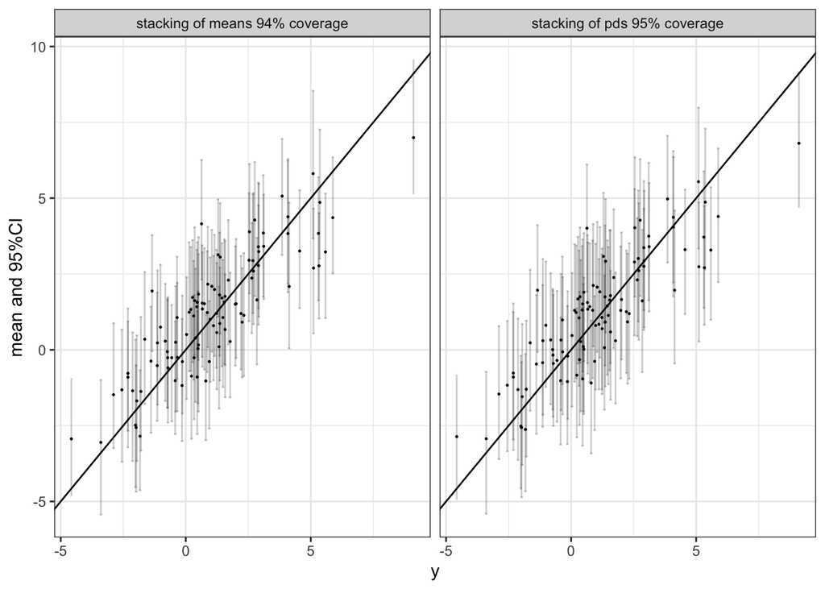

```r
library(ggplot2)
library(dplyr)
# Assuming y, ind_mod, pos_sam_LP$pred_y_U_stack_sam, and pos_sam_LSE$pred_y_U_stack_sam are defined
# Function to calculate means and CIs
calculate_means_and_cis <- function(pos_sam) {
  row_means <- rowMeans(pos_sam)
  CI <- apply(pos_sam, 1,
              function(x){quantile(x, probs = c(0.025, 0.975))})
  data.frame(
    mean = row_means,
    lower = CI[1, ],
    upper = CI[2, ]
  )
}

# check y prediction #
lp_data <- calculate_means_and_cis(pos_sam_LP$pred_y_U_stack_sam)
lp_data$x <- y[-ind_mod]
cover_lp <- round(sum(lp_data$lower<lp_data$x & lp_data$upper>lp_data$x) /
  length(lp_data$x) *100, 1)
label_lp <- paste0('stacking of pds ', cover_lp,"% coverage")
lp_data$source <- label_lp
lse_data <- calculate_means_and_cis(pos_sam_LSE$pred_y_U_stack_sam)
lse_data$x <-  y[-ind_mod]
cover_lse <- round(sum(lse_data$lower<lse_data$x & lse_data$upper>lse_data$x) /
                    length(lse_data$x) *100, 1)
label_lse <- paste0('stacking of means ', cover_lse, "% coverage")
lse_data$source <- label_lse

# Combine data
combined_data <- rbind(lse_data, lp_data)
combined_data$source <- factor(combined_data$source,
                               levels = c(label_lse, label_lp))

# Determine the common range for x and y if not already known
x_range <- range(combined_data$x, na.rm = TRUE)
y_range <- range(combined_data$mean, combined_data$lower, combined_data$upper, na.rm = TRUE)
# Plot
pts_y <- ggplot(combined_data, aes(x = x, y = mean)) +
  geom_point(size = 0.2) +
  geom_errorbar(aes(ymin = lower, ymax = upper), width = 0.1, alpha = 0.2) +
  geom_abline(intercept = 0, slope = 1) +
  facet_wrap(~ source) +  # Use 'free_x' to unify y range
  scale_x_continuous(limits = x_range) +
  scale_y_continuous(limits = y_range) +
  theme_bw() +
  labs(x = "y", y = "mean and 95%CI")
pts_y
```